# Case Study three: Vexing Voter Varieties

Author

Hadiya Cabdi

## Intro:

Voter turnout has been inconsistent in the 2024 presidential election where a third of eligible Americans chose not to vote for reasons unknown or undisclosed. It sparked a lot of questions for political organisations and statisticians like myself. That is why in this case study as a statistical consultant working for a local political organisation i will be answering who constitutes an infrequent voter by looking at data set consisted of responses from 5000 U.S. citizens collected by FiveThirtyEight in collaboration with Ipsos. Respondents were asked a variety of questions about their political beliefs, thoughts on current issues and voting behavior. Some of the variables we are going to explore in this case study are:

- page: The age of respondent in years.
- educ: highest educational attainment, which is represented categorically.
- race: self-reported race and ethnicity of the respondent, using census categories except “Hispanic” are non Hispanic
- gender: self-reported gender of the respondent
- income_cat: household income, represented categorically
- Q30: self-reported political affiliation directly answer the question of ” Generally speaking do you think of yourself as a …” Its divided as the following: Republican(1), Democrat(2), Independent(3), Another Party(4), and No preference(5).
- voter_category: past voting behavior, categorized as:
1. “always”, meaning the respondent voted in all or all-but-one of the elections they were eligible in)
2. “sporadic”, meaning the respondent voted in at least two, but fewer than all-but-one, of the elections they were eligible in
3. “rarely/never”, meaning the respondent voted in 0 or 1 of the elections they were eligible in.

The main questions that will be answered or explored in this case study is as follows:

## Primary Goal:

- Does political party affiliation plays a role in an individual’s likelihood of voting. If so, what is the nature of this relationship?
- 500 new people recently signed up for our mailing list, and we would like to send infrequent voters a personalized message encouraging them to vote. Based on the patterns you find at the national level, can you identify which of these people are likely to be infrequent voters? If so, how reliable is this categorization?

## Process:

First step is to load all of our packages and data:

```r
library(tidyverse)

ipsos_poll <- read.csv(
  "http://drive.google.com/uc?export=download&id=1nIQA5HMbvrdYDlpEJcTPzArBkSUp87gc",
  na.strings = c(-1, "NA")
  ) |>
  select(ppage, educ, race, gender, income_cat, Q30, voter_category) |>
  mutate(infrequent_voter = ifelse(voter_category == "rarely/never", 1, 0))

new_members <- read.csv(
  "https://drive.google.com/uc?export=download&id=1lxNnBoi73P2LAS3cM5GMs8LuNwPiXMFN",
  na.strings = c(-1, "NA")
  ) |>
  select(ppage, educ, race, gender, income_cat, Q30, voter_category)
```

### Wrangling data:

Now that we have all of our data loaded we will look for NA/Missing variables and instead of removing them i will be using an indicator method, to create an additional category labeled “Missing” for each categorical variable. This replaces any NA values and allows us to retain all of individuals instead of dropping observations with missing data. This approach treats missingness as potentially informative.

```r
ipsos_poll <- ipsos_poll |>
  mutate(across(c(educ, race, gender, income_cat, Q30),
                ~forcats::fct_na_value_to_level(as.factor(.), level = "Missing")))
```

## Q1: Does political party affiliation plays a role in an individual’s likelihood of voting. If so, what is the nature of this relationship?

A visualization of all of the political parties in q30 is measured using the indicator function, which represents 0 as those who are frequent voters and 1 indicating those who are infrequent voters in each political affiliation. We have numbers 1 through 5 in the graph, which represent the following political parties + missing group:

- 1: Republican
- 2: Democrat
- 3: Independent
- 4: Another Party
- 5: No preference
- Missing group

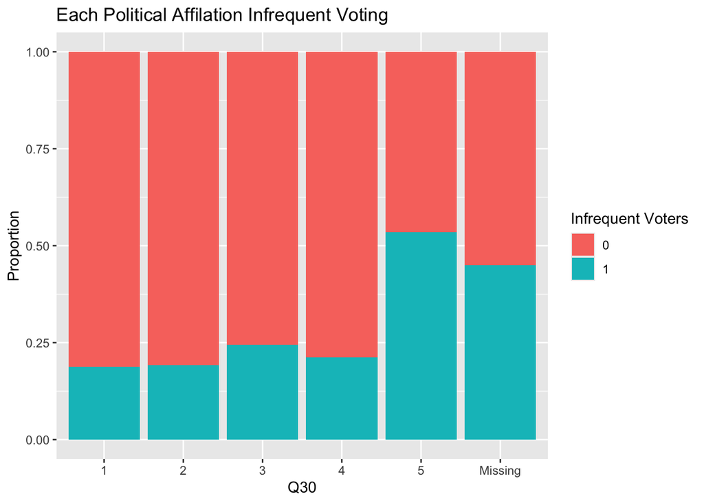

```r
ipsos_poll |>
  ggplot(aes(x = Q30, fill = factor(infrequent_voter))) +
  geom_bar(position = "fill") +
  labs(y = "Proportion",
       fill = "Infrequent Voters",
       title = "Each Political Affilation Infrequent Voting")
```

Individuals with no party preference and independents appear more likely to be infrequent voters, while Democrats and Republicans show lower proportions of infrequent voting. There is also a high number of infrequent voters due to missingness. To further show this isn’t a noise or random we can compute the model and compute significance distribution test.

### Signifacance test/Hypothesis:

Our null hypothesis is
$$H_0: B_j = 0$$
:

- The variable has no effect on voting, which corresponds to odds ratio of 1.

Alternative hypothesis
$$H_A doesnt = 0$$
:

- Which means the variable does affect voting behavior.

### Model 1:

Using the logistic regression model we estimate a probability of each individual being an infrequent voter.
$$P(Y = 1) = P(infrequent voter)$$
It produces a probability between 0 and 1 for each person. For example a predicted value like 0.88 indicates a very high likelihood being an infrequent voter. The model assumes:
$$log(p/1-p) = B_0 +B_1Q30 + B_2ppage+ B_3educ + B_4income_cat + B_5race + B6_gender$$

```r
model_1 <- glm(infrequent_voter ~ Q30 + ppage + educ + income_cat + race + gender,
             data = ipsos_poll,
             family = "binomial")

summary(model_1)
```

```
Call:
glm(formula = infrequent_voter ~ Q30 + ppage + educ + income_cat +
    race + gender, family = "binomial", data = ipsos_poll)

Coefficients:
                          Estimate Std. Error z value Pr(>|z|)
(Intercept)               0.473426   0.193974   2.441  0.01466 *
Q302                     -0.106184   0.102235  -1.039  0.29898
Q303                      0.275731   0.102418   2.692  0.00710 **
Q304                     -0.216133   0.289859  -0.746  0.45588
Q305                      1.107516   0.117342   9.438  < 2e-16 ***
Q30Missing                1.172188   0.365712   3.205  0.00135 **
ppage                    -0.052319   0.002348 -22.283  < 2e-16 ***
educHigh school or less   0.988029   0.097417  10.142  < 2e-16 ***
educSome college          0.266260   0.095299   2.794  0.00521 **
income_cat$40-75k         0.058117   0.112031   0.519  0.60393
income_cat$75-125k       -0.068220   0.106931  -0.638  0.52349
income_catLess than $40k  0.567525   0.113714   4.991 6.01e-07 ***
raceHispanic              0.085199   0.129754   0.657  0.51143
raceOther/Mixed           0.396268   0.162025   2.446  0.01446 *
raceWhite                 0.055309   0.109010   0.507  0.61189
genderMale                0.166344   0.072660   2.289  0.02206 *
---
Signif. codes:  0 '***' 0.001 '**' 0.01 '*' 0.05 '.' 0.1 ' ' 1

(Dispersion parameter for binomial family taken to be 1)

    Null deviance: 5952.4  on 5335  degrees of freedom
Residual deviance: 4891.9  on 5320  degrees of freedom
AIC: 4923.9

Number of Fisher Scoring iterations: 5
```

### Interpretation:

If we convert our significant variables to odds ratio we will have have the following.

```r
exp(coef(model_1))
```

```
             (Intercept)                     Q302                     Q303
               1.6054848                0.8992589                1.3174931
                    Q304                     Q305               Q30Missing
               0.8056284                3.0268293                3.2290509
                   ppage  educHigh school or less         educSome college
               0.9490260                2.6859366                1.3050740
       income_cat$40-75k       income_cat$75-125k income_catLess than $40k
               1.0598388                0.9340553                1.7638957
            raceHispanic          raceOther/Mixed                raceWhite
               1.0889336                1.4862679                1.0568670
              genderMale
               1.1809796
```

## Odds Ratio/Interpretation:

### Confidence Interval:

```r
# your code here
exp(confint(model_1))
```

```
                             2.5 %    97.5 %
(Intercept)              1.0975861 2.3482305
Q302                     0.7360260 1.0989847
Q303                     1.0780156 1.6107798
Q304                     0.4450880 1.3943502
Q305                     2.4061566 3.8119004
Q30Missing               1.5588561 6.5864887
ppage                    0.9446302 0.9533663
educHigh school or less  2.2203709 3.2531701
educSome college         1.0825810 1.5730414
income_cat$40-75k        0.8510332 1.3204897
income_cat$75-125k       0.7576231 1.1522874
income_catLess than $40k 1.4123316 2.2058789
raceHispanic             0.8444370 1.4045764
raceOther/Mixed          1.0803287 2.0396375
raceWhite                0.8545732 1.3103862
genderMale               1.0243460 1.3619656
```

This reinforces the previous explanation that weaker political affiliation as well as socioeconomic status typically associate with high likelihood of infrequent voting.

## Results for Q1:

In contrast the difference between democrats and republicans are not statistically significant with a p_value of 0.299. That is why political party affiliations play a role in an individual’s likelihood of voting, and the nature of the relationship is that political engagement typically increases with stronger party identification.

### Q2:500 new people recently signed up for our mailing list, and we would like to send infrequent voters a personalized message encouraging them to vote. Based on the patterns you find at the national level, can you identify which of these people are likely to be infrequent voters? If so, how reliable is this categorization?

```r
library(forcats)

new_members <- new_members |>
  mutate(across(c(educ, race, gender, income_cat, Q30),
                ~fct_na_value_to_level(as.factor(.), level = "Missing")))
```

```r
# Probability predictions

new_members$pred_prob <- predict(model_1, newdata = new_members, type = "response")
```

In order to turn probabilities to decisions that we can interpret we will have to create a threshold of 0.5, to classify whether individuals will be labeled as an infrequent voter if probability is greater than 0.5 or not.

```r
# Classification (threshold = 0.5)
new_members$pred_class <- ifelse(new_members$pred_prob > 0.5, 1, 0)
```

After that we will have to see how many of the classification are predicted to be infrequent voters:

```r
table(new_members$pred_class)
```

```
  0   1
438  62
```

We observe that 62 people out of the 500 new members are classified as infrequent voters while the rest 438 are classified to be regular voters. Although it might represent relatively a small number which is about(12.4%) it identifies a meaningful subset of individuals who could benefit from targeted outreach.

To better understand these individuals we examine those who are with the highest predicted probabilities.

```r
# Top likely infrequent voters
head(new_members[order(-new_members$pred_prob),])
```

```
    ppage                educ        race gender     income_cat Q30
155    31 High school or less Other/Mixed   Male Less than $40k   5
185    27 High school or less       Black   Male Less than $40k   5
65     29 High school or less       White   Male Less than $40k   5
124    31 High school or less       White   Male Less than $40k   5
406    35 High school or less       White   Male Less than $40k   5
23     22 High school or less       White Female       $75-125k   5
    voter_category pred_prob pred_class
155   rarely/never 0.8886691          1
185   rarely/never 0.8687813          1
65        sporadic 0.8630547          1
124   rarely/never 0.8502112          1
406   rarely/never 0.8215644          1
23    rarely/never 0.8029826          1
```

## Interpretation:

We can see that the individuals with the highest predicted probability(around 0.80 - 0.89) exhibit constant characteristics. Most belong to Q30 category 5(no party preference) which have lower levels of education(high school or less), and lower income levels(less than $40k). The model associated infrequent voting to lower socioeconomic status and weak political affiliation. However we have to note that those socioeconomic variables are also boosting the odds and together create a very high probability. For example, individuals with no party preference already have substantially higher odds of being infrequent voters as previously established, and when combined with lower education, lower income, and younger age, the predicted probability increases further.

Nevertheless the model isnt perfect. For instance the model is picking up someone who looks like an infrequent voter based on their socioeconomic background. An individual labeled as sporadic voter is assigned a high predicted probability of ~0.86.

A sporadic voter belongs to the “Voter Category” variable which defines it as:

- sporadic”: the respondent voted in at least two, but fewer than all-but-one, of the elections they were eligible in.

However for this part of the analysis we are interested in the Voter category,

- “rarely/never”, meaning the respondent voted in 0 or 1 of the elections they were eligible in.

  This shows that our model depends on statistical patterns rather than exact classification. Therefore some misclassifications are to be expected. However it doesn’t change anything from the rest of our predictions.

  We can further explore how reliable the model is by assessing its performance using predicted probabilities on the original data set.

### Reliability:

```r
ipsos_poll$pred_prob <- predict(model_1, type = "response")
ipsos_poll$pred_class <- ifelse(ipsos_poll$pred_prob > 0.5, 1, 0)

matrix <- table(Predicted = ipsos_poll$pred_class,
                     Actual = ipsos_poll$infrequent_voter)

matrix
```

```
         Actual
Predicted    0    1
        0 3786  899
        1  238  413
```

# Roc Curve:

We can use the Receiver Operating Characteristic(ROC) curve rather then relying only on a single classification threshold to evaluate model performance across all possible thresholds.

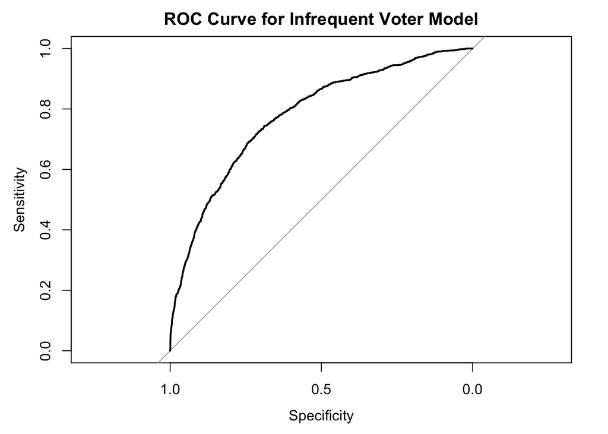

```r
library(pROC)

roc <- roc(ipsos_poll$infrequent_voter, ipsos_poll$pred_prob)
plot(roc, main = "ROC Curve for Infrequent Voter Model")
```

Area under curve(AUC): will further help us summaries the model’s overall ability to distinguish between infrequent and frequent voters:

```r
auc(roc)
```

```
Area under the curve: 0.7795
```

Our area under curve is 0.7795 which indicates moderate performance. It means that the model is reasonable effective separating the infrequent and frequent voters, however is not perfect.

## Results for Q2:

# Conclusion:

Using Logistic regression, Hypothesis testing, predictions, and Roc analysis we find that political affiliation in fact plays a significant role in voting behavior. Individuals with weaker political affiliation and lower socioeconomic backgrounds especially the no preference group and independent have higher odds of being infrequent voters according to our model analysis. 62 individuals out of the 500 new members were identified to be infrequent voters which could be good for the targeted outreach. The area under the curve shows moderate predictive performance which performs better than random classification. It is more better predicting frequent voters than infrequent voters, but provides a useful information and approach for targeting infrequent voters. Results should be interpreted with caution as its not a perfect model.